# IPV Detection in NVDRS Suicide Narratives - Production Analysis

Analysis Report

2025-11-24 09:52:54

## Overview

This analysis examines **35,312** suicide narratives from **19,985** unique incidents in the NVDRS database from 2017 to 2022. We successfully processed **35,312** narratives with only **1** operational errors (**0.0028%** error rate) completing execution in **48.8** hours.

The analysis employed the **mlx-community/gpt-oss-120b** model with temperature **0.2**, detecting intimate partner violence (IPV) in **5.65%** of narratives (narrative level) and in **8.42%** of the incidents (incident level, IPV detected in either the CME or LE narrative). ⚠️ These results represent patterns in unlabeled data and should be interpreted as exploratory findings rather than validated performance metrics.

# 1. Data Structure & Quality

Understanding the structure and quality of the underlying data is essential for interpreting detection results. This section examines the narrative type distribution, incident-level completeness, and temporal coverage.

## 1.1 Narrative Type Distribution

NVDRS death investigations produce two distinct narrative types: Chief Medical Examiner (CME) narratives documenting autopsy and medical findings, and Law Enforcement (LE) narratives describing investigative details. Understanding this distribution can be helpful because these sources may capture different aspects of IPV indicators.

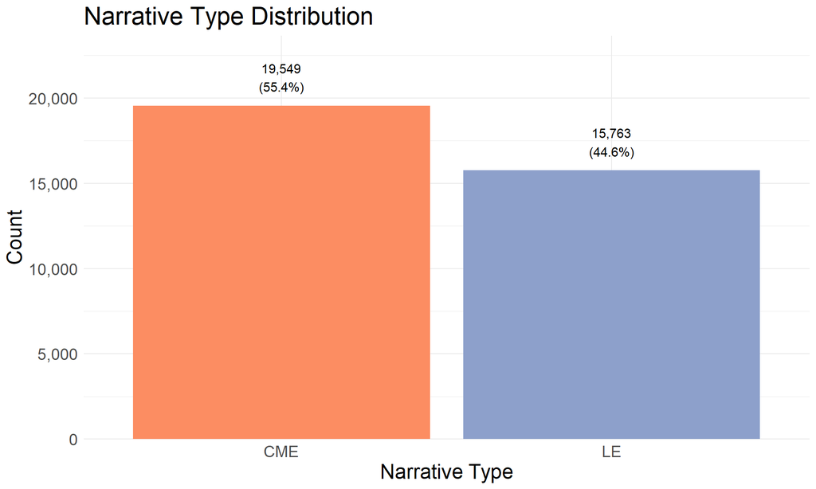

The distribution reveals a slight imbalance, with CME narratives comprising **55.4%** of the dataset compared to **44.6%** for LE narratives.

## 1.2 Incident-Level Completeness

We next breakdown the incident level completeness, how many incidents have both CME and LE narratives and how many have only one type. Incidents with both CME and LE reports may provide us more information and opportunities to detect IPV than if we only had one report.

Incident-Level Narrative Completeness

| Completeness Category | Incidents (N = 19,985) | Percentage |
| --- | --- | --- |
| Both CME and LE | 15,327 | 76.69 |
| CME only | 4,222 | 21.13 |
| LE only | 436 | 2.18 |

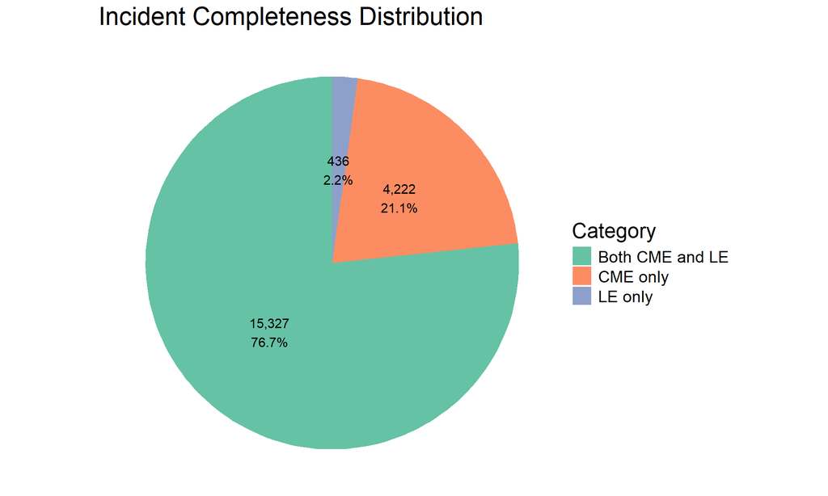

The pie chart reveals that **15,327** incidents (**76.7%**) have both CME and LE narratives available. The remaining incidents have only one narrative type, either due to jurisdictional reporting practices or data access limitations. This high dual-narrative rate strengthens our ability to detect IPV using two sources of information.

## 1.3 Data Quality - Placeholders

Not all narratives contain substantial information, as some are **placeholders** indicating missing or unavailable reports. Example of placeholder narratives include: “No CME report available”, “No LE report available”, “Death certificate only”, etc.

Additionally, some cases only have **brief** narratives that we define as having less than 100 characters. These brief narratives may limit the model’s ability to detect IPV indicators due to insufficient context. Examples of brief narratives include: “V (17 year old white female) hanged herself at home. No further circumstances.”.

For the narratives with more text, we split them into two groups and define **standard** narratives as those between 100-500 characters and **detailed** narratives as those over 500 characters.

Overall Narrative Data Quality Summary

| Quality Category | Count | Percentage |
| --- | --- | --- |
| Placeholder | 1,952 | 5.53 |
| Brief | 160 | 0.45 |
| Standard | 8,948 | 25.34 |
| Detailed | 24,252 | 68.68 |

CME Narrative Data Quality Summary

| Quality Category | Count | Percentage |
| --- | --- | --- |
| Placeholder | 370 | 1.89 |
| Brief | 67 | 0.34 |
| Standard | 4,988 | 25.52 |
| Detailed | 14,124 | 72.25 |

LE Narrative Data Quality Summary

| Quality Category | Count | Percentage |
| --- | --- | --- |
| Placeholder | 1,582 | 10.04 |
| Brief | 93 | 0.59 |
| Standard | 3,960 | 25.12 |
| Detailed | 10,128 | 64.25 |

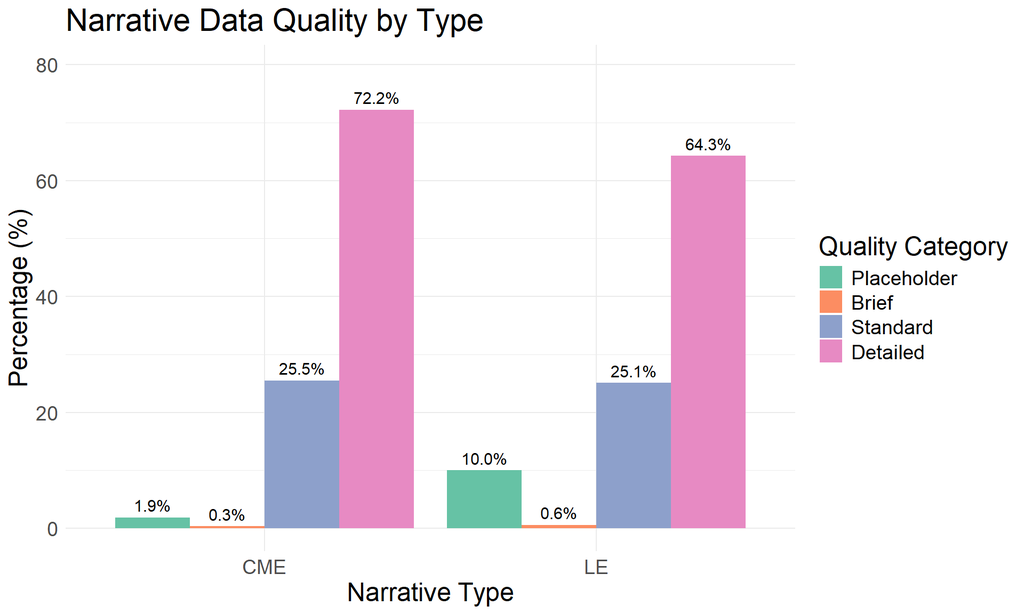

The data quality assessment identifies a small proportion of narratives as placeholders (**5.53%**). When we break it down by narrative type, we find only **1.89%** of CME, but **10.04%** of LE narratives classified as placeholders. Most narratives fall into the standard or detailed categories, indicating sufficient information for IPV detection. The presence of placeholders and brief narratives is expected but minimal, suggesting overall good data quality for analysis.

## 1.4 Temporal Distribution

Temporal coverage is important for understanding whether detection patterns vary over time and for assessing the generalizability of findings across different calendar years.

### 1.4.1 *Narrative Level Year Distribution*

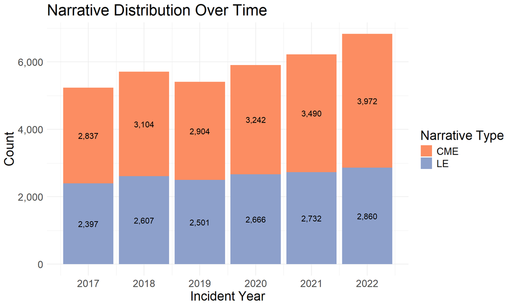

### 1.4.2 *Incident Level Year Distribution*

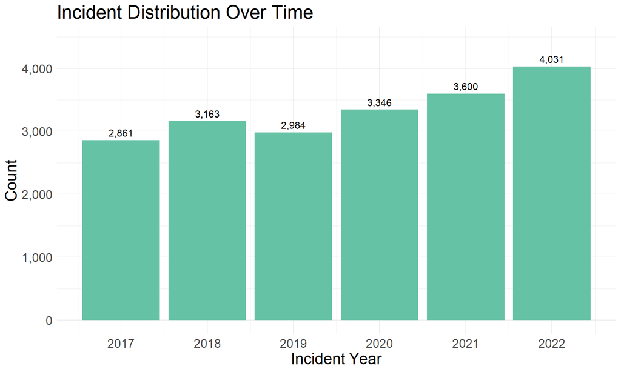

The data spans **6** years from **2017** to **2022**, providing comprehensive temporal coverage. The bar charts show a slightly increasing number of incidents, and therefore narratives as well, across years.

### 1.4.3 *Incidents by State Over Time*

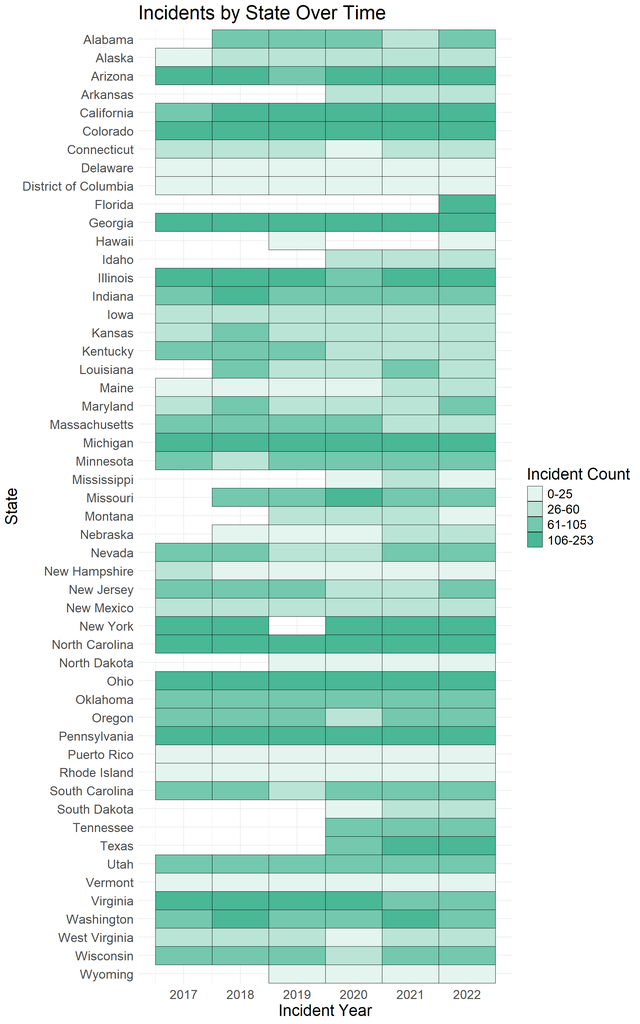

The heatmap illustrates the distribution of incidents across states and years. We observe variability in incident counts by state, with some states consistently reporting higher numbers of incidents over time. This also highlights the states for which we are missing data due to when each state joined NVDRS.

# 2. Detection Patterns

Detection patterns reveal how frequently the model identifies IPV indicators and whether rates differ systematically by narrative source, or time period. These patterns provide insight into both the prevalence of IPV-related language in suicide narratives and potential biases in documentation practices.

## 2.1 Overall Detection Rates

Understanding baseline detection rates at the narrative-level by narrative type and the incident level is fundamental to interpreting model behavior. CME and LE narratives may differ in IPV indicator prevalence due to their distinct documentation focuses—medical versus investigative perspectives. Additionally, these narratives are extracted by NVDRS abstractors therefore adding another layer of potential loss of information.

### *2.1.1 Narrative Level*

IPV Detection by Narrative Type and Overall

| Type | Total | Detected | Detection Rate % |
| --- | --- | --- | --- |
| CME | 19,549 | 1,088 | 5.57 |
| LE | 15,763 | 907 | 5.75 |
| Total | 35,312 | 1,995 | 5.65 |

Across both CME and LE narratives, we have a narrative-level detection rate of **5.65%**. We found that CME and LE narratives have similar detection rates, with **LE** narratives exhibiting only a **0.19** percentage point higher detection rate than **CME** narratives.

### *2.1.2 Incident Level*

IPV Detection at Incident Level

| Total Incidents | Detected Incidents | Detection Rate % |
| --- | --- | --- |
| 19,985 | 1,682 | 8.42 |

When we look at detection at the incident level (i.e., whether any narrative for an incident indicated IPV), we find a detection rate of **8.42%** which is higher compared to narrative-level detection. This increase is expected since incidents with multiple narratives have more opportunities for IPV indicators to be documented in at least one source.

## 2.2 Data Quality Impact on Detection

Data quality may influence detection rates, as placeholder or brief narratives likely contain insufficient information for the model to identify IPV indicators. We examine detection rates stratified by narrative quality categories to assess this impact.

IPV Detection by Narrative Quality and Type

| Quality Category | Total | Detected | Detection Rate % |
| --- | --- | --- | --- |
| Placeholder | 1,952 | 0 | 0.00 |
| Brief | 160 | 0 | 0.00 |
| Standard | 8,948 | 174 | 1.94 |
| Detailed | 24,252 | 1,821 | 7.51 |

We find that placeholders and brief narrative do not detect IPV which is what we expected, especially with the placeholders as they provide no information about the incident. Comparing the standard and detailed narratives, the detailed narratives achieved the highest IPV detection rate of **7.51%**. This pattern confirms that richer narrative content enhances the model’s ability to identify IPV indicators, underscoring the importance of data quality.

## 2.3 Temporal Detection Patterns

Temporal trends in detection rates may reflect evolving documentation practices, or changes in IPV prevalence.

### 2.3.1 *Narrative Level Over Time*

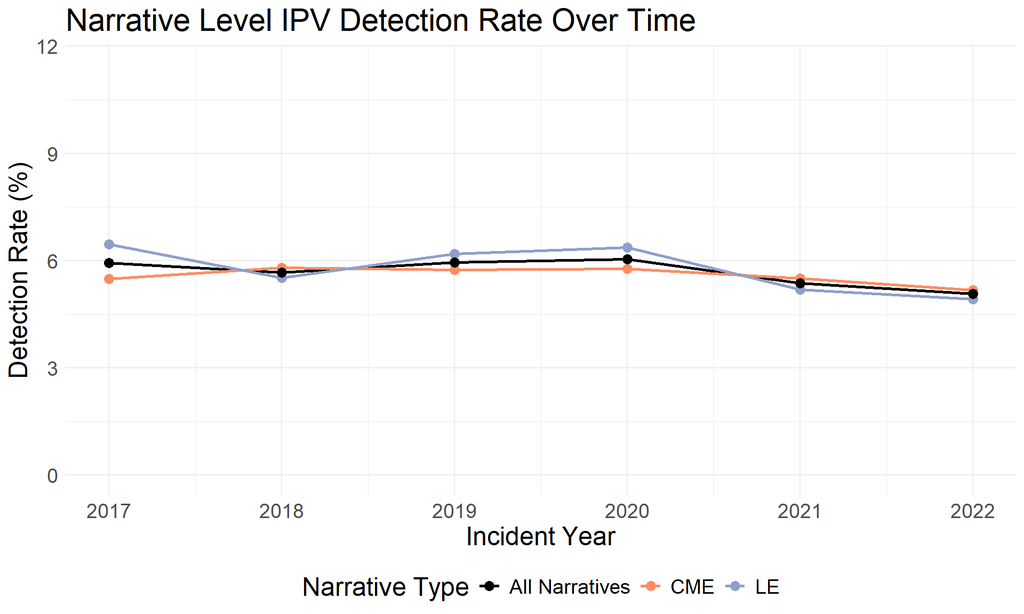

The temporal trend reveals only slight year-to-year fluctuations in detection rates for both narrative types. While some variation is expected due to sample size differences and natural population changes, the general patterns suggest relatively stable detection behavior over the study period.

### 2.3.2 *Incident Level Over Time*

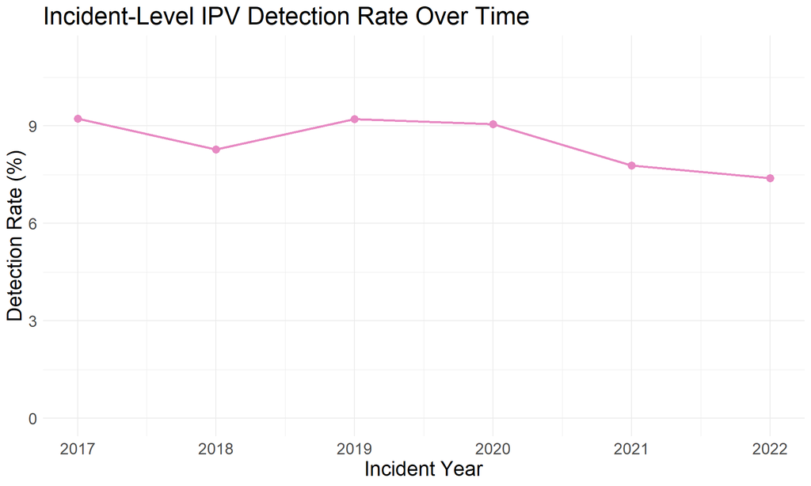

At the incident level, we see higher rates of detection overall, but the temporal trends remain relatively stable until 2020 where we see a slight downshift. This could be due to a multitude of factors such as NVDRS documentation practices or data limitations, or external factors affecting IPV related suicides during that period.

## 2.4 Detection by State and Year

### *2.4.1 By State*

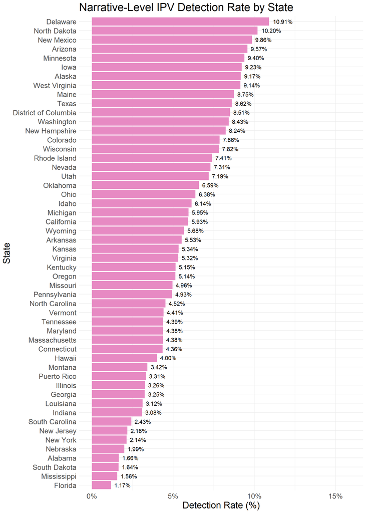

The bar chart illustrates variability in detection rates across states, ranging from **1.17%** to **10.91%**. These differences may reflect state-level variations in IPV prevalence, documentation practices, or other contextual factors influencing narrative content. *Due to low counts in some states, these detection rates should be interpreted cautiously.*

### *2.4.2 By State Over Time*

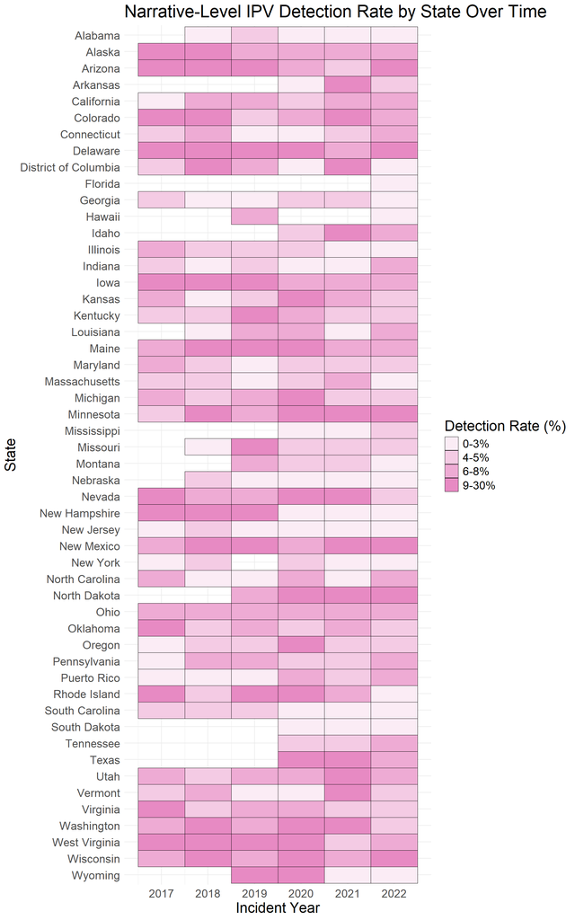

The heatmap reveals considerable variability in detection rates across states and years. Some states consistently exhibit higher detection rates, while others remain low throughout the study period. This heterogeneity may reflect differences in IPV prevalence, reporting practices, or other contextual factors influencing narrative content and model performance. *Due to low counts in some state-year combinations, these detection rates should be interpreted cautiously.*

# 3. Confidence Analysis

Confidence scores reflect the model’s certainty in its predictions. Well-calibrated confidence should correlate with prediction accuracy—though we lack ground truth labels, examining confidence distributions by detection outcome and narrative type reveals whether the model exhibits systematic uncertainty patterns.

## 3.1 Confidence Distribution

Understanding the overall distribution of confidence scores helps assess whether the model makes predictions with appropriate levels of certainty or shows extreme overconfidence/underconfidence patterns.

Confidence Score Summary Statistics

| Mean | Median | SD | Min | Max |
| --- | --- | --- | --- | --- |
| 0.89 | 0.90 | 0.06 | 0.00 | 0.96 |

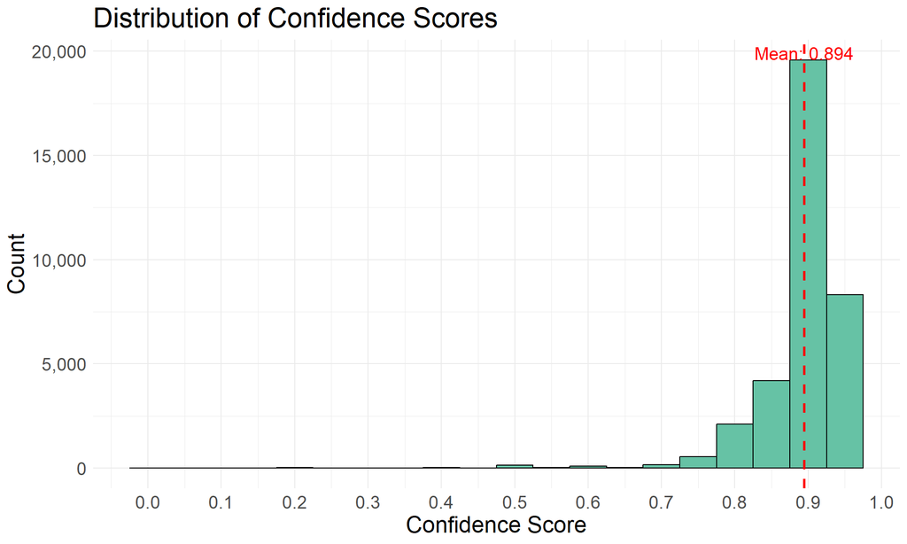

## 3.2 Confidence by Detection Outcome

Comparing confidence distributions between IPV-positive and IPV-negative predictions reveals whether the model exhibits differential certainty patterns. Systematic differences may indicate distinct confidence profiles for the two prediction types.

Confidence Statistics by Detection Outcome

| Detection | Count | Mean | Median | SD |
| --- | --- | --- | --- | --- |
| IPV Detected | 1,995 | 0.865 | 0.88 | 0.059 |
| No IPV | 33,315 | 0.896 | 0.90 | 0.065 |

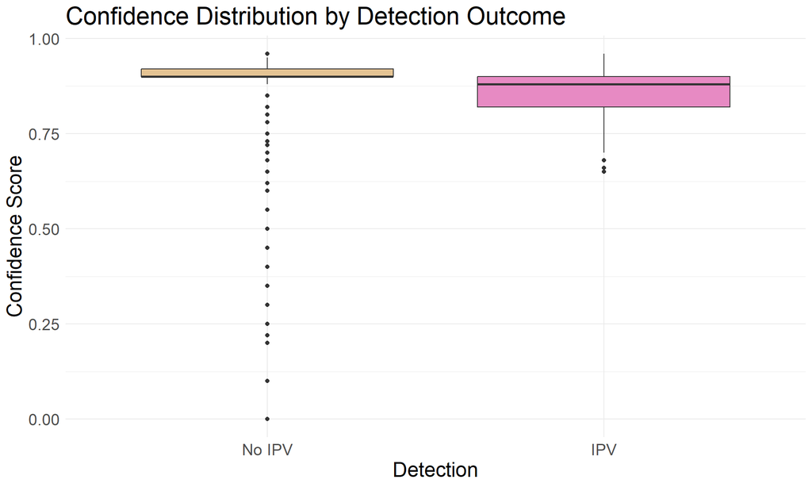

The boxplots reveal distinct confidence profiles between detection outcomes. IPV detections show a mean confidence of **0.865**, while non-detections average **0.896**—a difference of **0.031**. The table confirms these patterns with both mean and median statistics. The non-detections have more instances of lower confidence scores but both distributions show substantial confidence levels indicating the model makes relatively decisive predictions in both cases.

## 3.3 Confidence by Narrative Type

Examining whether confidence patterns differ between CME and LE narratives helps identify whether the model’s certainty is influenced by narrative source characteristics. Systematic differences could reflect variations in documentation completeness or indicator clarity across narrative types.

Confidence by Narrative Type and Detection

| Narrative Type | IPV Detected | Count | Mean | Median |
| --- | --- | --- | --- | --- |
| CME | No | 18,460 | 0.901 | 0.90 |
| CME | Yes | 1,088 | 0.867 | 0.90 |
| LE | No | 14,855 | 0.889 | 0.90 |
| LE | Yes | 907 | 0.862 | 0.85 |

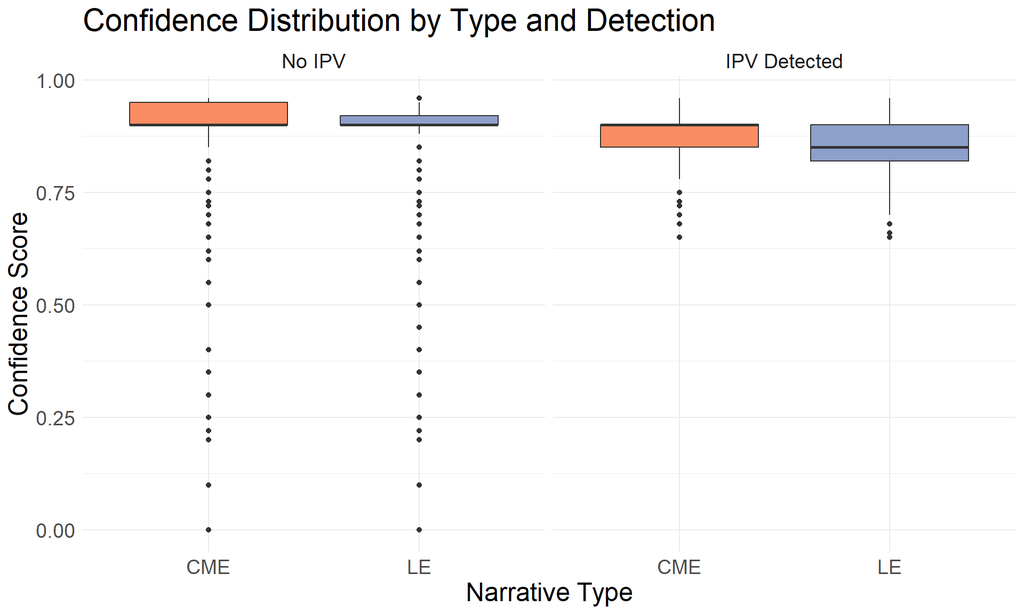

# 4. Indicators and Reasoning Analysis

Beyond binary detection outcomes, the model generates structured indicators and reasoning chains that explain its decisions. Examining these outputs reveals what specific signals drive IPV detection and whether the model provides coherent, evidence-based rationales. This transparency is essential for building trust in automated detection systems.

## 4.1 Indicator Extraction

The model is designed to extract and structure specific IPV indicators alongside detection decisions. Analyzing these indicators reveals the concrete signals that trigger positive detections and enables qualitative assessment of detection reasoning quality.

Sample Indicators from IPV Detections

| Incident ID | Narrative Type | Confidence | Indicators |
| --- | --- | --- | --- |
| 686801 | LE | 0.85 | Domestic issues |
| 878295 | LE | 0.90 | psychological abuse; emotional abuse |
| 585135 | LE | 0.90 | Restraining order against partner |
| 1222649 | CME | 0.80 | domestic issues |
| 690087 | LE | 0.92 | domestic violence; physical abuse |
| 1137718 | CME | 0.90 | physical abuse |
| 987673 | CME | 0.85 | domestic violence |
| 641420 | CME | 0.90 | physical abuse |
| 537957 | CME | 0.88 | domestic violence; partner arrested for DV |
| 1178485 | LE | 0.88 | partner arrested for DV |

## 4.2 Reasoning Length Analysis

**Reasoning chains** document the model’s step-by-step logic for reaching detection decisions. Analyzing reasoning length patterns reveals whether IPV-positive detections receive more elaborate justification than negatives, potentially indicating greater examination for positive findings.

Reasoning Length by Detection Outcome

| IPV Detected | Count | Avg Rationale Length | Avg Reasoning Length |
| --- | --- | --- | --- |
| No | 33,315 | 135.2 | 867.5 |
| Yes | 1,995 | 137.2 | 2,264.9 |

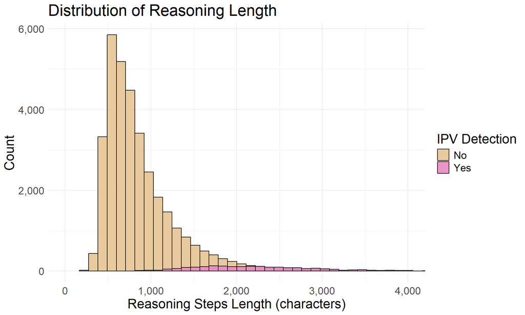

The analysis reveals that IPV-positive detections generate reasoning chains averaging **2265** characters, compared to **868** characters for non-detections—a difference of **1397** characters. This suggests the model provides more detailed justification when identifying IPV indicators. The overlapping histogram distributions indicate that both detection types receive substantive reasoning rather than brief explanations. The rationale field shows similar patterns (table above), confirming consistent efforts across detection outcomes.

## 4.3 Confidence vs Reasoning Length

Exploring the relationship between reasoning length and confidence reveals whether the model expresses higher certainty with more elaborate reasoning or whether confidence is independent of explanation detail. This helps assess whether reasoning chains add genuine value beyond binary predictions.

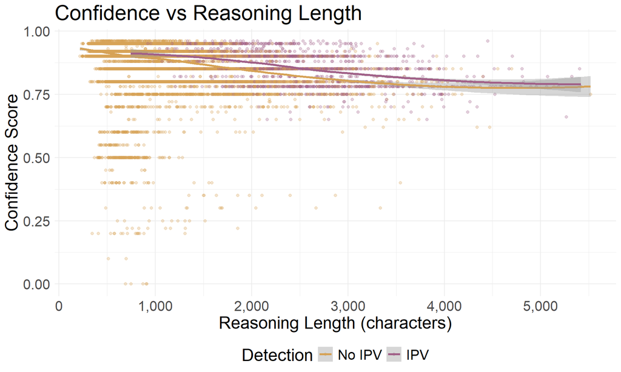

The scatterplot with LOESS smoothing curves reveals the relationship between reasoning length and confidence across detection types. For both IPV detections (pink) and non-detections (tan), the trend lines suggest a slightly decreasing confidence across reasoning lengths, but the longer reasoning lengths appear to have less of a spread in confidence scores with majority of confidence scores high compared to shorter reasoning lengths. The substantial scatter around the curves indicates that reasoning length alone does not determine confidence—the model considers content quality beyond mere explanation verbosity. The separate curves for each detection type show similar patterns, suggesting consistent confidence-reasoning dynamics regardless of outcome.

# 5. Key Findings & Implications

## 5.1 Completeness and Data Quality

The incident-level completeness analysis reveals that **76.7%** of incidents have both CME and LE narratives available, providing comprehensive documentation from multiple perspectives. The remaining **23.3%** have only one narrative type. We find that a low percent of narratives are placeholders or brief narratives (**6.0%**), indicating overall good data quality for analysis.

## 5.2 Overall Detection Rates

IPV was detected in **5.65%** of all narratives. Detection rates varied by narrative type: CME narratives showed **5.57%** detection, while LE narratives demonstrated **5.75%** detection.

At the incident level, **8.42%** of incidents had at least one narrative indicating IPV, reflecting the cumulative detection potential when multiple narratives are available.

## 5.3 Confidence Patterns

The model exhibited a mean confidence score of **0.894** (median: **0.900**) across all predictions. The majority of confidence scores remained high regardless of detection outcome, but non-detection narratives appeared to encompass the lower confidence scores over the IPV detected narratives.

## 5.4 Limitations

1. **No Validation Data**: Cannot assess accuracy, precision, or recall
2. **Temporal Variation**: Detection rates vary by year (see section 2.3)
3. **Single Model**: Results reflect one model configuration only (mlx-community/gpt-oss-120b, T=0.2)